# PCA Demo

March 12, 2019

## Source

- A lot of R codes in this demo are taken from R codes in the excellent book "Introduction to Statistical Learning with Applications in R" by James, Witten, Hastie and Tibshirani. The Book website has R codes, labs and lots of other resources http://www.statlearning.com/.
- The Crime data and Iris data codes were provided by Dr. Sumanta Basu.

## Recap (PCA)

- In practice, we observe \(n\) observations of the \((x_1, \ldots, x_p)\).
- Let \(X\) be a data matrix with \(n\) rows and \(p\) columns. Subtract the column mean from each variable.
- The first principal component direction is the vector \(\beta_1 = (\beta_{11}, \ldots, \beta_{p1})'\) s.t. \[ \max_{\beta_{11}, \ldots, \beta_{p1}} \left\{ \frac{1}{n} \left( \sum_{j=1}^{p} \beta_{j1} x_{ij} \right)^2 \right\} \text{ subject to } \sum_{j=1}^{p}\beta_{j1}^2 = 1 \]

## Recap (PCA)

\[ \max_{\beta_{11}, \ldots, \beta_{p1}} \left\{ \frac{1}{n} \left( \sum_{j=1}^{p} \beta_{j1} x_{ij} \right)^2 \right\} \text{ subject to } \sum_{j=1}^{p}\beta_{j1}^2 = 1 \]

- \(\sum_{j=1}^{p} \beta_{j1} x_{ij}\): Projection of \(i^{th}\) sample into \(\beta_1\) - also called score \(y_{i1}\).
- Maximize: Sample variance of the scores \(y_{i1}\).

## Second PC

- The second principal component direction is the vector \(\beta_2 = (\beta_{12}, \ldots, \beta_{p2})'\) s.t. \[ \max_{\beta_{12}, \ldots, \beta_{p2}} \left\{ \frac{1}{n} \left( \sum_{j=1}^{p} \beta_{j2} x_{ij} \right)^2 \right\} \\ \text{ subject to } \sum_{j=1}^{p}\beta_{j2}^2 = 1, \sum_{j=1}^{p}\beta_{j1} \beta_{j2} = 0 \]
- First and second principal components must be orthogonal.
- Scores \((y_{i1}, i = 1, \ldots, n)\) and \((y_{i2}, i = 1, \ldots, n)\) are independent.

## Optimization for PCA

- PCA can be performed in two different ways:
- The singular value decomposition of \(X\): \[ X = U \Sigma B^{T} \] where the \(i\)-th column of \(B\) is the \(i\)-th principal component direction \(\beta_i\).
- The Eigen-Decomposition of \(X^TX\): \[ X^T X = B \Sigma^2 B^T \]

## Using R

- Two packages `prcomp` and `princomp`.
- Difference:

prcomp: The calculation is done by a singular value decomposition of the (centered and possibly scaled) data matrix, not by using eigen on the covariance matrix. This is generally the preferred method for numerical accuracy.

primcomp: uses Eigen-decomposition.

## US Arrest data

Reminiscient of the US Crime data, but different.

Description

This data set contains statistics, in arrests per 100,000 residents for assault, murder, and rape in each of the 50 US states in 1973. Also given is the percent of the population living in urban areas.

## Data

```r
states=row.names(USArrests)
states
```

```
##  [1] "Alabama"        "Alaska"         "Arizona"        "Arkansas"
##  [5] "California"     "Colorado"       "Connecticut"    "Delaware"
##  [9] "Florida"        "Georgia"        "Hawaii"         "Idaho"
## [13] "Illinois"       "Indiana"        "Iowa"           "Kansas"
## [17] "Kentucky"       "Louisiana"      "Maine"          "Maryland"
## [21] "Massachusetts"  "Michigan"       "Minnesota"      "Mississippi"
## [25] "Missouri"       "Montana"        "Nebraska"       "Nevada"
## [29] "New Hampshire"  "New Jersey"     "New Mexico"     "New York"
## [33] "North Carolina" "North Dakota"   "Ohio"           "Oklahoma"
## [37] "Oregon"         "Pennsylvania"   "Rhode Island"   "South Carolina"
## [41] "South Dakota"   "Tennessee"      "Texas"          "Utah"
## [45] "Vermont"        "Virginia"       "Washington"     "West Virginia"
## [49] "Wisconsin"      "Wyoming"
```

## Variable Names

```r
names(USArrests)
```

```
## [1] "Murder"   "Assault"  "UrbanPop" "Rape"
```

```r
apply(USArrests, 2, mean)
```

```
##   Murder  Assault UrbanPop     Rape
##    7.788  170.760   65.540   21.232
```

```r
apply(USArrests, 2, var)
```

```
##     Murder    Assault   UrbanPop       Rape
##   18.97047 6945.16571  209.51878   87.72916
```

- If we failed to scale the variables before performing PCA, then most of the principal components that we observed would be driven by the Assault variable, since it has by far the largest mean and variance.

## PCA

```r
pr.out=prcomp(USArrests, scale=TRUE)
names(pr.out)
```

```
## [1] "sdev"     "rotation" "center"   "scale"    "x"
```

```r
pr.out$center
```

```
##   Murder  Assault UrbanPop     Rape
##    7.788  170.760   65.540   21.232
```

```r
pr.out$scale
```

```
##    Murder   Assault  UrbanPop      Rape
##  4.355510 83.337661 14.474763  9.366385
```

## Loadings

The rotation matrix provides the principal component loadings; each column of `pr.out$rotation` contains the corresponding principal component loading vector.

```r
pr.out$rotation
```

```
##                 PC1        PC2        PC3         PC4
## Murder   -0.5358995  0.4181809 -0.3412327  0.64922780
## Assault  -0.5831836  0.1879856 -0.2681484 -0.74340748
## UrbanPop -0.2781909 -0.8728062 -0.3780158  0.13387773
## Rape     -0.5434321 -0.1673186  0.8177779  0.08902432
```

```r
dim(pr.out$x)
```

```
## [1] 50  4
```

## Biplots

- Biplot provides an efficient way of visualizing together objects (observations) and variables.
- The emphasis of the PCA of the city crime data was on cities (objects).
- However, a graphical representation of the data that contains some information about the variables is particularly useful.

## Biplot

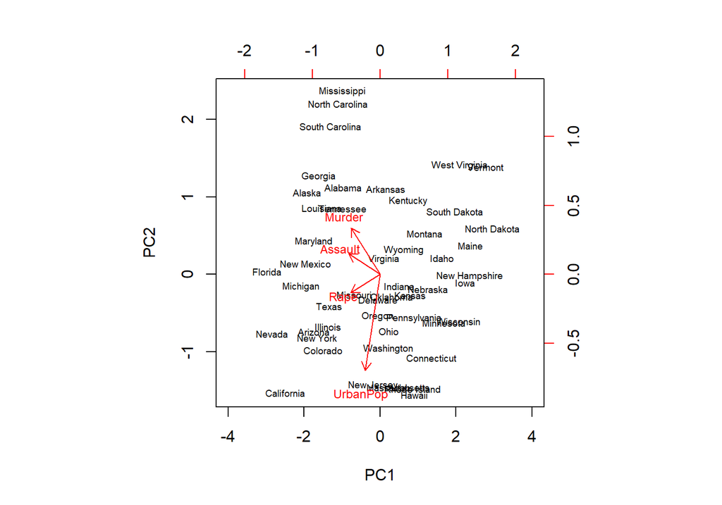

```r
biplot(pr.out, scale=0,  cex=c(0.6, 0.75),xlim=c(-4,4))
```

The scale=0 argument to biplot() ensures that the arrows are scaled to represent the loadings.

## Fancier version

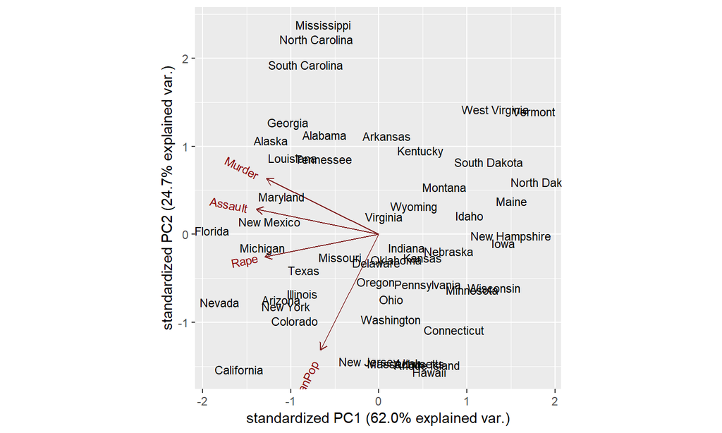

```r
# library(devtools); install_github("vqv/ggbiplot")
library(ggbiplot)
ggbiplot(pr.out, labels =  rownames(USArrests))
```

## Biplot

**The principal components are only unique up to a sign change**

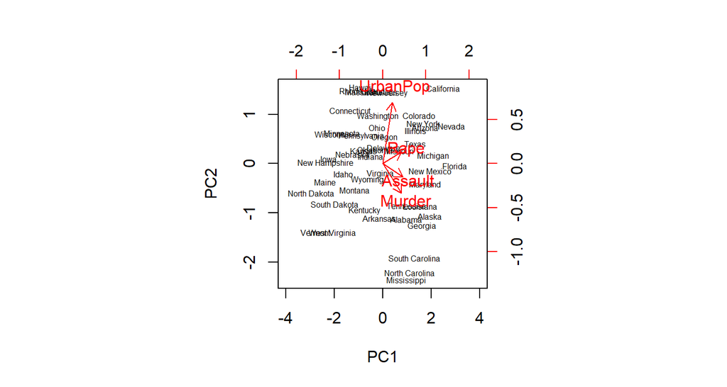

```r
pr.out$rotation=-pr.out$rotation; pr.out$x=-pr.out$x
biplot(pr.out, scale=0,cex=c(1/2, 1),xlim=c(-4,4))
```

## Importance of Scaling

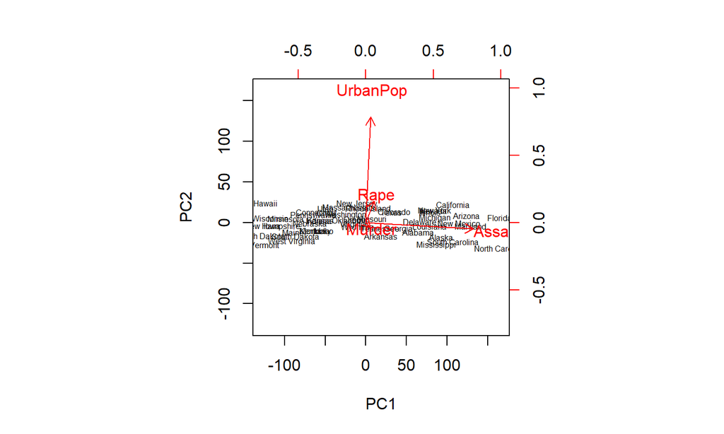

```r
biplot(prcomp(USArrests, scale = F), scale=0, cex=c(1/2, 1))
```

## Standard Deviations

```r
pr.out$sdev
```

```
## [1] 1.5748783 0.9948694 0.5971291 0.4164494
```

```r
pr.var=pr.out$sdev^2
pr.var
```

```
## [1] 2.4802416 0.9897652 0.3565632 0.1734301
```

```r
pve=pr.var/sum(pr.var)
pve
```

```
## [1] 0.62006039 0.24744129 0.08914080 0.04335752
```

## Proportion of Variance Explained

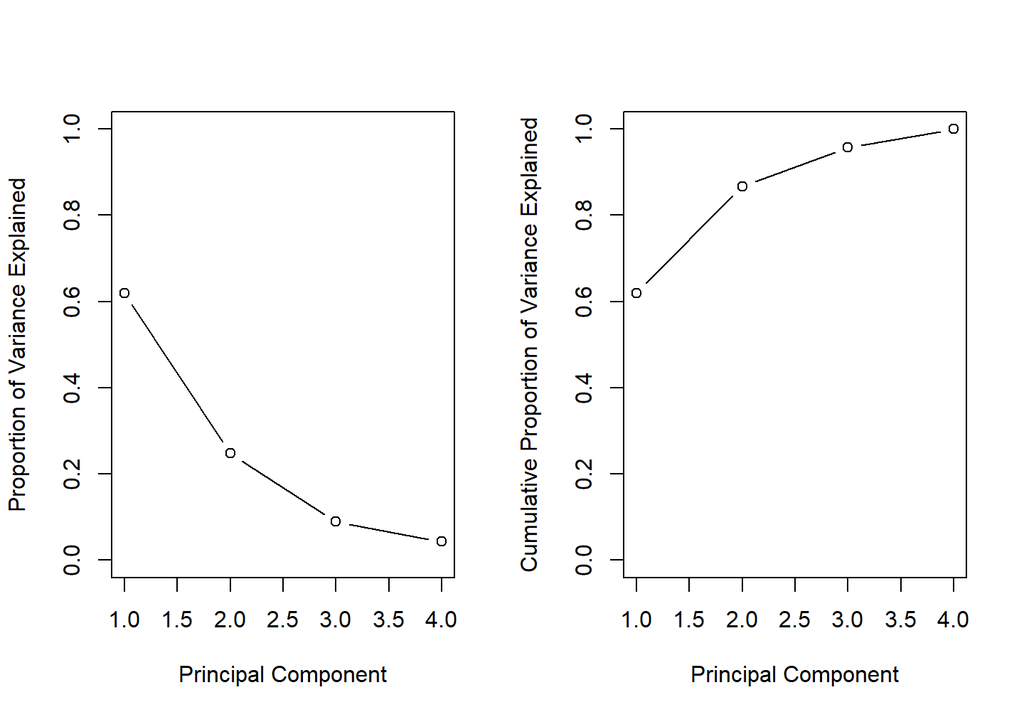

## More Examples

- Now we will see two more examples, using the princomp package.
- Recall that the `prcomp` and `princomp` package both performs PCA. One does SVD on the \(X\) matrix and the other does Eigen-decomposition on the \(X^TX\) matrix.
- They are **almost** identical althouch `prcomp` is preferred by some.

## PCA for Crime Data-set

The following R commands perform PCA on the city crime dataset. The data give crime rates per 100,000 people for the 72 largest US cities in 1994.

The variables are: 1) Murder 2) Rape 3) Robbery 4) Assault 5) Burglary 6) Larceny 7) Motor Vehicle Thefts

## The Data

The data are in the "city_crime.txt" file that I read next.

```r
setwd("C:/Users/jd033/OneDrive/Documents/Course Notes/stat5443/R codes")
crime<-read.table("city_crime.txt")
```

- This is city-wise crime data rather than state-wise like the last example.

## Scatterplot Matrix

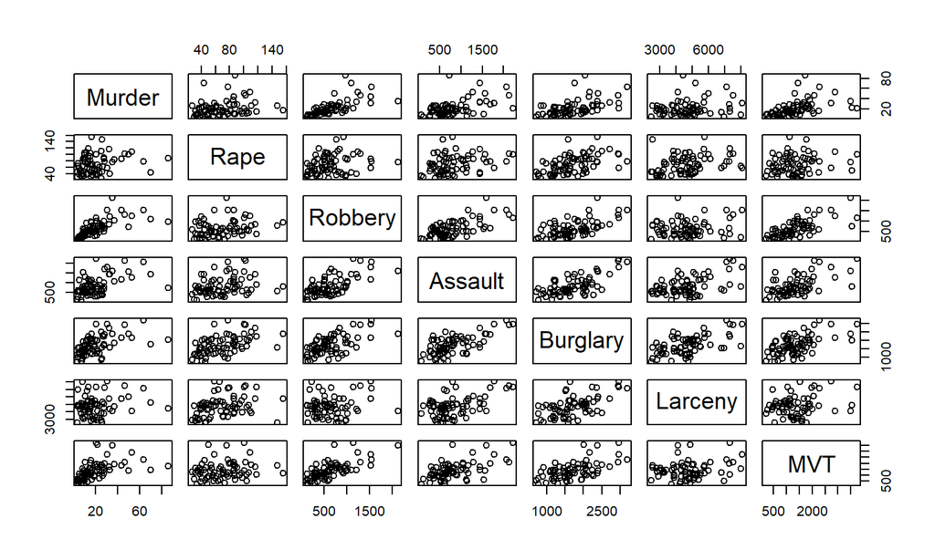

```r
pairs(crime)
```

## R

Then apply PCA on the data by rescaling and centering the data using the R function `princomp`:

```r
pca.crime<-princomp(scale(crime,scale=TRUE,center=TRUE),cor=FALSE)
```

## Look at the results

```r
summary(pca.crime)
```

```
## Importance of components:
##                          Comp.1    Comp.2    Comp.3     Comp.4     Comp.5
## Standard deviation     1.934449 1.0873855 0.8710005 0.70936242 0.57288477
## Proportion of Variance 0.542114 0.1712944 0.1099039 0.07289747 0.04754564
## Cumulative Proportion  0.542114 0.7134084 0.8233123 0.89620976 0.94375539
##                           Comp.6     Comp.7
## Standard deviation     0.4585486 0.42187341
## Proportion of Variance 0.0304612 0.02578341
## Cumulative Proportion  0.9742166 1.00000000
```

## Loadings

```r
loadings(pca.crime)
```

```
##
## Loadings:
##          Comp.1 Comp.2 Comp.3 Comp.4 Comp.5 Comp.6 Comp.7
## Murder    0.370  0.339  0.202  0.717  0.277  0.220  0.262
## Rape      0.249 -0.467  0.783 -0.159         0.267
## Robbery   0.426  0.388               -0.194 -0.147 -0.776
## Assault   0.434        -0.282        -0.767  0.118  0.358
## Burglary  0.450 -0.238                0.242 -0.794  0.220
## Larceny   0.276 -0.606 -0.492  0.209  0.264  0.303 -0.331
## MVT       0.390  0.303 -0.134 -0.644  0.399  0.351  0.204
##
##                Comp.1 Comp.2 Comp.3 Comp.4 Comp.5 Comp.6 Comp.7
## SS loadings     1.000  1.000  1.000  1.000  1.000  1.000  1.000
## Proportion Var  0.143  0.143  0.143  0.143  0.143  0.143  0.143
## Cumulative Var  0.143  0.286  0.429  0.571  0.714  0.857  1.000
```

## Proportion of Variance

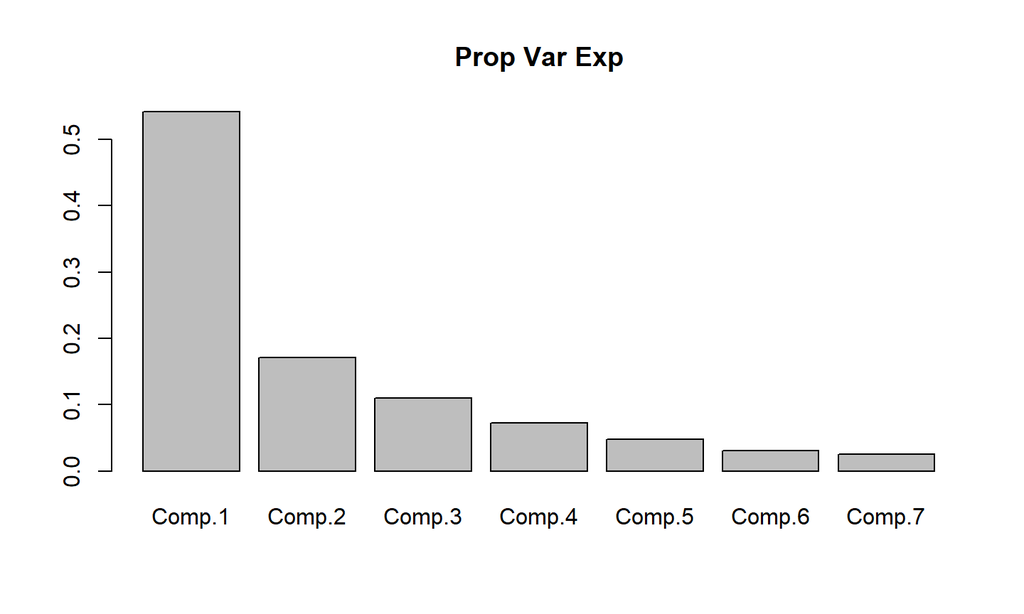

```r
PoV <- pca.crime$sdev^2/sum(pca.crime$sdev^2)
barplot(PoV, main="Prop Var Exp")
```

## How many?

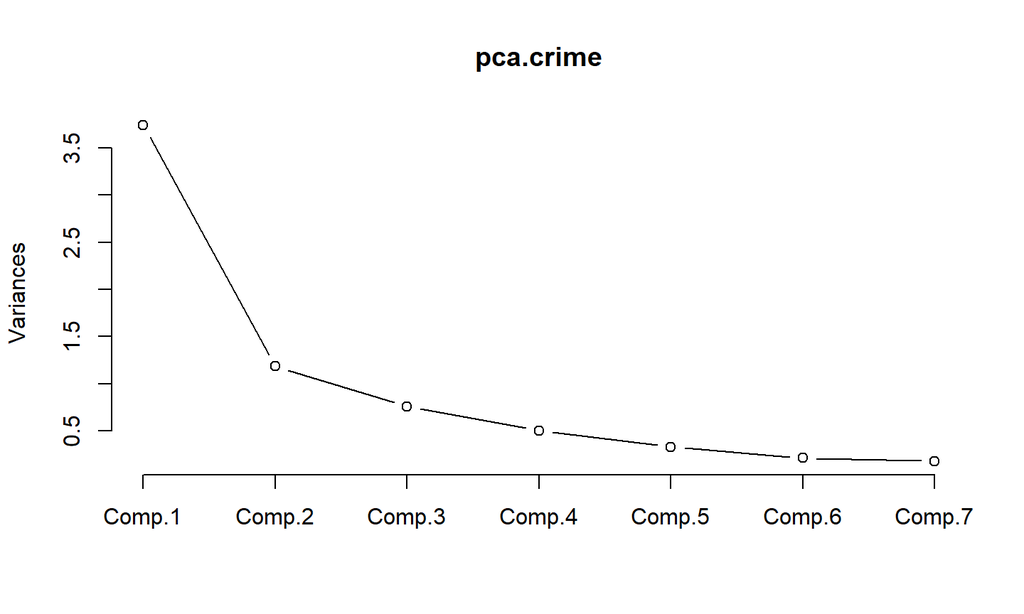

```r
screeplot(pca.crime, type="line")
```

## Calculate the principal component scores

Once we calculate the principal components, we can plot them against each other in order to produce low-dimensional views of the data.

First we calculate the principal component scores.

```r
pcs.crime<-predict(pca.crime)
```

## Plot the first 2 PCs.

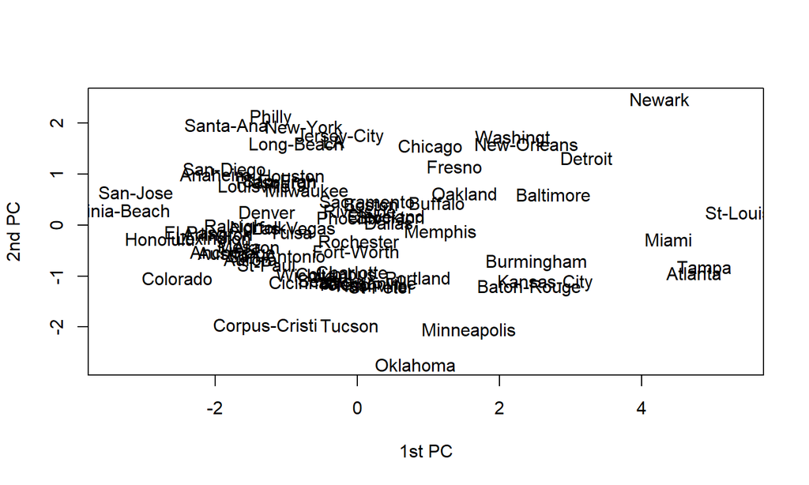

```r
plot(pcs.crime[,1:2],type="n",xlab='1st PC',ylab='2nd PC')
text(pcs.crime[,1:2],row.names(crime))
```

## Biplot

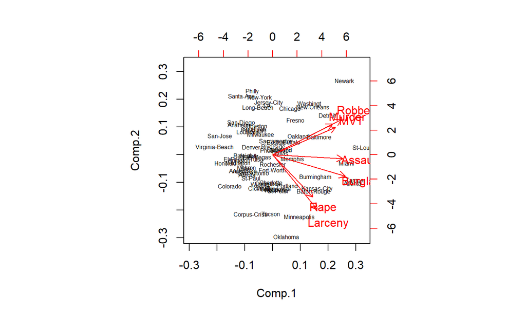

```r
biplot(pca.crime, cex = c(0.5,1))
```

## Questions

1. Which cities are most safe? Which are most crime-prone?
2. How to interpret high/low values in the second PC?

## Subtle difference

- For scaling, `prcomp` uses \(n-1\) as denominator but `princomp` uses \(n\) as its denominator.

```r
pc.cr<-prcomp(crime, scale=TRUE, cor=TRUE, scores=TRUE)
pc.cr1<-princomp(crime, scale=TRUE, cor=TRUE, scores=TRUE)
pc.cr$scale
```

```
##     Murder       Rape    Robbery    Assault   Burglary    Larceny
##   15.49703   28.21087  394.73973  474.47209  562.34922 1345.85980
##        MVT
##  728.40358
```

```r
pc.cr1$scale
```

```
##     Murder       Rape    Robbery    Assault   Burglary    Larceny
##   15.38904   28.01427  391.98890  471.16562  558.43036 1336.48087
##        MVT
##  723.32753
```

## Iris Data

```r
data(iris)
str(iris)
```

```
## 'data.frame':    150 obs. of  5 variables:
##  $ Sepal.Length: num  5.1 4.9 4.7 4.6 5 5.4 4.6 5 4.4 4.9 ...
##  $ Sepal.Width : num  3.5 3 3.2 3.1 3.6 3.9 3.4 3.4 2.9 3.1 ...
##  $ Petal.Length: num  1.4 1.4 1.3 1.5 1.4 1.7 1.4 1.5 1.4 1.5 ...
##  $ Petal.Width : num  0.2 0.2 0.2 0.2 0.2 0.4 0.3 0.2 0.2 0.1 ...
##  $ Species     : Factor w/ 3 levels "setosa","versicolor",..: 1 1 1 1 1 1 1 1 1 1 ...
```

```r
dat.iris = data.matrix(iris[,1:4])
```

## Add noise and shuffle columns

```r
dat.iris = cbind(dat.iris, array(rnorm(150*6), c(150, 6)))
colnames(dat.iris)[5:10] <- paste('V', 1:6, sep='')
dat.iris = dat.iris[,sample(10, 10, replace=FALSE)]
```

- Now we have original variables as well as noise variables but we don't know which is which. Let's see if PCA can still detect the species.

## Center and Scale before PCA

```r
dat.iris = scale(dat.iris, center=TRUE, scale=TRUE)
```

Perform principal component analysis on correlation matrix

```r
pca.iris <- princomp(dat.iris, cor=TRUE)
```

## Summarize PCA

```r
summary(pca.iris)
```

```
## Importance of components:
##                           Comp.1    Comp.2    Comp.3    Comp.4     Comp.5
## Standard deviation     1.7159958 1.1066430 1.1013361 1.0326773 0.99834832
## Proportion of Variance 0.2944642 0.1224659 0.1212941 0.1066423 0.09966994
## Cumulative Proportion  0.2944642 0.4169300 0.5382242 0.6448664 0.74453635
##                            Comp.6     Comp.7     Comp.8     Comp.9
## Standard deviation     0.91558184 0.90169810 0.86654437 0.36327725
## Proportion of Variance 0.08382901 0.08130595 0.07508991 0.01319704
## Cumulative Proportion  0.82836537 0.90967131 0.98476123 0.99795826
##                            Comp.10
## Standard deviation     0.142889407
## Proportion of Variance 0.002041738
## Cumulative Proportion  1.000000000
```

## Choose no. of PCs to look into

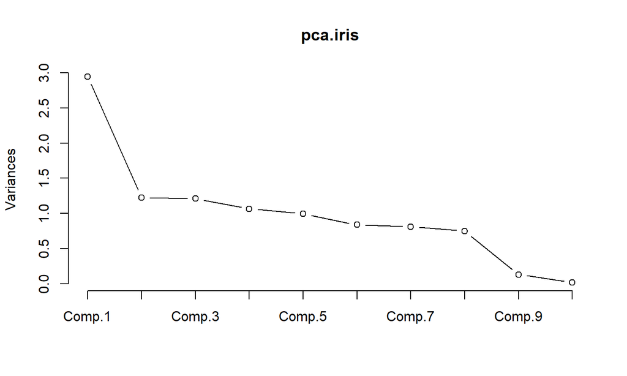

```r
screeplot(pca.iris, type="line")
```

## Calculate PC scores

```r
pcs.iris <- predict(pca.iris)
```

Set color code for observations from different groups

```r
col.code = as.character(iris$Species)
col.code[col.code == "setosa"] = 'red'
col.code[col.code == "versicolor"] = 'blue'
col.code[col.code == "virginica"] = 'green'
```

## Plot first two principal components

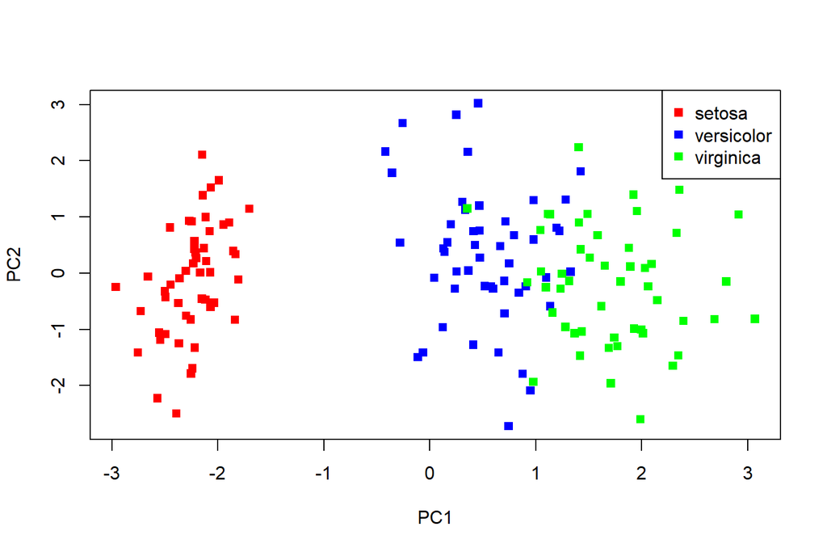

```r
plot(pcs.iris[,1:2], type='p', pch=15, col=col.code, xlab="PC1", ylab="PC2")
legend("topright", col=c('red', 'blue', 'green')
     , legend = c('setosa', 'versicolor', 'virginica'), pch = 15
      )
```

## Importance of PC

- Plot first two variables \(X[,1:2]\) instead of the first two principal components.
- Do we see any clustering?

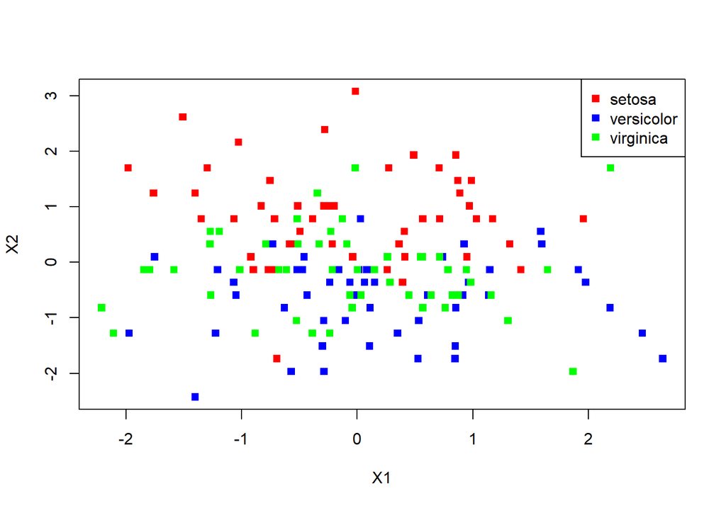

## Importance of PC

**When we have many variables, projecting observations into top few PC scores help avoid searching over important variables.**

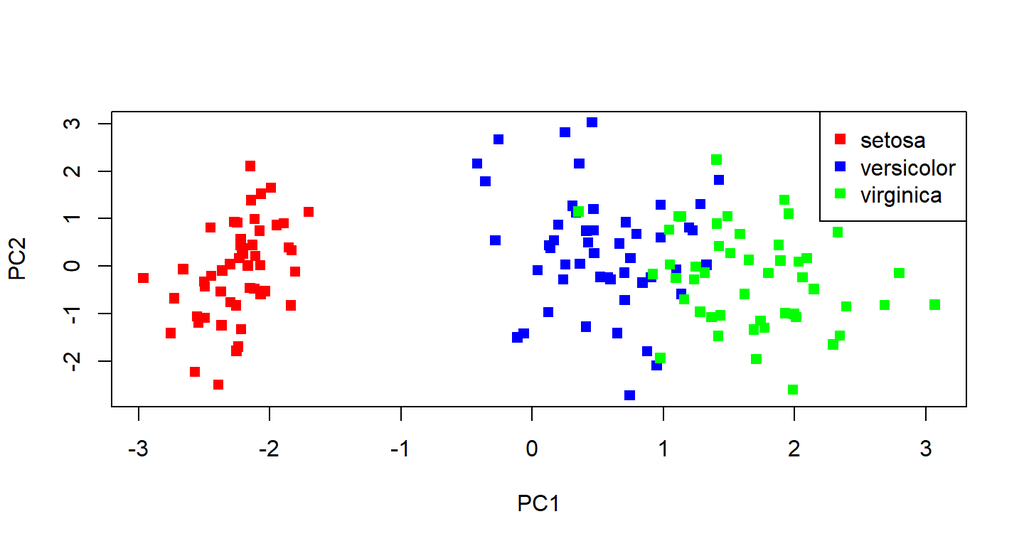